# CNN Data loading and sanity check

### Selection of the monitoring tool

Monitoring tools are important for efficient model creation. Core concept for developing a model is keeping track of training vs. validation behaviour over time. A monitoring tool makes this process more efficient and reliable. It can display loss and accuracy curves, weights and gradients, this helps detecting over- and underfitting, as well as bad learning rates. It speedas up the Hyperparameter tuning process, because it systematically tracks experiments and makes easy comparing possible. Over all, it helps to keep an overview over experiments and model testing, thus enables finding good models faster.  
There are multiple different solutions for monitoring tools. We have looked at three of them:

- TensorBoard
- Weights & Biases (W&B)
- MLFlow

```python
from src.cnn.cnn_paths import DATA_DIR, VAL_DIR, DATASET_DIR

'''Overview table'''
#| Feature               | TensorBoard       | Weights & Biases (W&B) | MLflow                   |
#| --------------------- | ----------------- | ---------------------- | ------------------------ |
#| Setup                 | Very easy (local) | Easy (cloud login)     | Medium (needs setup)     |
#| UI                    | Basic but solid   | Best-in-class          | Functional               |
#| Experiment tracking   | Limited           | Excellent              | Excellent                |
#| Hyperparameter sweeps | Manual            | Built-in, strong       | Possible but less smooth |
#| Collaboration         | Weak              | Strong (cloud)         | Medium                   |
#| Offline usage         | Yes               | Limited (sync later)   | Yes                      |
#| Framework integration | Native PyTorch/TF | Works with everything  | General ML               |
#| MLOps pipeline        | Weak              | Medium                 | Strong                   |
```

```
'Overview table'
```

## importing and setting up

```python
# Imports
import torch
from torchvision import datasets, transforms
import matplotlib.pyplot as plt
import os
from src.cnn.cnn_utils import *
```

## Loading and preparing the data

### Checking class distribution of the images

```python
# get_dataset_info(dataset)
```

[output not shown]

```python
# count number of images in each class of the validation dataset
data_dir = VAL_DIR

class_counts = {}

for class_name in os.listdir(data_dir):
    class_path = os.path.join(data_dir, class_name)

    if os.path.isdir(class_path):
        count = len([
            f for f in os.listdir(class_path)
            if os.path.isfile(os.path.join(class_path, f))
        ])
        class_counts[class_name] = count

# print nicely
for cls, count in sorted(class_counts.items()):
    print(f"{cls}: {count}")
```

```
cat: 600
chicken: 600
cow: 600
dog: 600
elephant: 600
horse: 600
rabbit: 600
sheep: 600
squirrel: 600
zebra: 600
```

All calsses are evenly balanced.

### Loading the data

```python
from src.cnn.cnn_paths import TRAIN_DIR

# define image size
# Original image size 224x224, can be changed to 128x128 or 64x64 for faster training but may reduce accuracy
size = 224

# Transformer to ensure all images are the same size and converted to tensors
transformer = transforms.Compose([
    transforms.Resize((size, size)), # transform to desired size
    transforms.ToTensor(), # transforms into tensor
])
# comment: only the basic data normalization is applied, no standardization of mean and std

# load training and validation dataset
train_dataset = datasets.ImageFolder(root=TRAIN_DIR, transform=transformer)
val_dataset = datasets.ImageFolder(root=VAL_DIR, transform=transformer)
```

```python
# check dataset sizes
print(f"Training dataset size: {len(train_dataset)}")
print(f"Validation dataset size: {len(val_dataset)}")
```

```
Training dataset size: 24000
Validation dataset size: 6000
```

```python
seed = torch.Generator().manual_seed(42)

train_dataset, test_dataset = torch.utils.data.random_split(train_dataset, [len(train_dataset) - 4000, 4000], generator=seed)
```

```python
# check dataset sizes
print(f"Training dataset size: {len(train_dataset)}")
print(f"Validation dataset size: {len(val_dataset)}")
print(f"Test dataset size: {len(test_dataset)}")
```

```
Training dataset size: 20000
Validation dataset size: 6000
Test dataset size: 4000
```

```
Dataset:
  num_samples: 24000
  num_classes: 10
  class distribution:
    cat: 2400
    chicken: 2400
    cow: 2400
    dog: 2400
    elephant: 2400
    horse: 2400
    rabbit: 2400
    sheep: 2400
    squirrel: 2400
    zebra: 2400
```

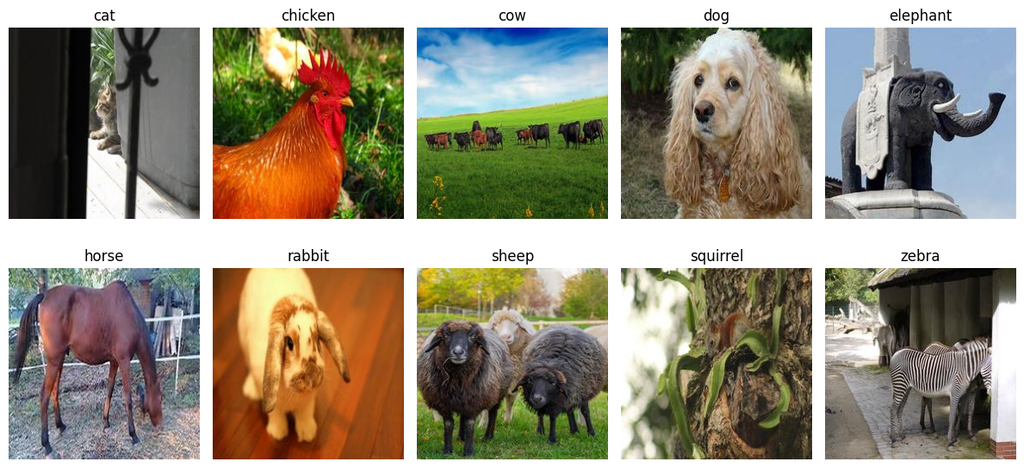

```python
# print one image per class from the test dataset
dataset = test_dataset.dataset

from src.cnn.cnn_utils import print_dataset_info
print_dataset_info(dataset, to_plot=True)
```

### Save splited dataset for reuse in other notebooks

```python
torch.save({
    'train_idx': train_dataset.indices,
    'test_idx': test_dataset.indices
}, '../../01_MPW-CNN/data/split/split_train_test_indices.pth')
```

#### Code for loading the same dataset in other notebooks:

alternative way would be with .py files

```python
# code snippet for loading same dataset with the saved indices

transformer = transforms.Compose([
    transforms.Resize((224, 224)), # transform to size = 224x224
    transforms.ToTensor(), # transforms into tensor
])

full_dataset = datasets.ImageFolder("../../01_MPW-CNN/data/icosimal_img_class_03/train", transform=transformer)
splits = torch.load("../../01_MPW-CNN/data/split/split_train_test_indices.pth")

train_dataset = torch.utils.data.Subset(full_dataset, splits['train_idx'])
test_dataset = torch.utils.data.Subset(full_dataset, splits['test_idx'])
val_dataset = datasets.ImageFolder("../../01_MPW-CNN/data/icosimal_img_class_03/validate", transform=transformer)
```

Note: 01.04.2026  
As discussed in the lecture of CNN part 2 the creation of a test set is not necessary.